# Risk Factor Analysis

## Outcome Variable

**Outcome Variable:** stunted

## Predictor Variables

**Intervention Variable:** mhtcm

**Adjustment Set:**

- arm
- W_mage
- meducyrs
- feducyrs
- single
- delta_W_mage
- delta_meducyrs
- delta_feducyrs
- delta_single

## Stratifying Variables

The analysis was stratified on these variable(s):

- agecat
- studyid
- country

## Data Summary

| agecat | studyid | country | mhtcm | stunted | n_cell | n |
| --- | --- | --- | --- | --- | --- | --- |
| Birth | ki0047075b-MAL-ED | BANGLADESH | >=155 cm | 0 | 22 | 246 |
| Birth | ki0047075b-MAL-ED | BANGLADESH | >=155 cm | 1 | 3 | 246 |
| Birth | ki0047075b-MAL-ED | BANGLADESH | <151 cm | 0 | 125 | 246 |
| Birth | ki0047075b-MAL-ED | BANGLADESH | <151 cm | 1 | 31 | 246 |
| Birth | ki0047075b-MAL-ED | BANGLADESH | [151-155) cm | 0 | 57 | 246 |
| Birth | ki0047075b-MAL-ED | BANGLADESH | [151-155) cm | 1 | 8 | 246 |
| Birth | ki0047075b-MAL-ED | BRAZIL | >=155 cm | 0 | 99 | 184 |
| Birth | ki0047075b-MAL-ED | BRAZIL | >=155 cm | 1 | 8 | 184 |
| Birth | ki0047075b-MAL-ED | BRAZIL | <151 cm | 0 | 40 | 184 |
| Birth | ki0047075b-MAL-ED | BRAZIL | <151 cm | 1 | 9 | 184 |
| Birth | ki0047075b-MAL-ED | BRAZIL | [151-155) cm | 0 | 26 | 184 |
| Birth | ki0047075b-MAL-ED | BRAZIL | [151-155) cm | 1 | 2 | 184 |
| Birth | ki0047075b-MAL-ED | INDIA | >=155 cm | 0 | 43 | 198 |
| Birth | ki0047075b-MAL-ED | INDIA | >=155 cm | 1 | 3 | 198 |
| Birth | ki0047075b-MAL-ED | INDIA | <151 cm | 0 | 76 | 198 |
| Birth | ki0047075b-MAL-ED | INDIA | <151 cm | 1 | 19 | 198 |
| Birth | ki0047075b-MAL-ED | INDIA | [151-155) cm | 0 | 47 | 198 |
| Birth | ki0047075b-MAL-ED | INDIA | [151-155) cm | 1 | 10 | 198 |
| Birth | ki0047075b-MAL-ED | NEPAL | >=155 cm | 0 | 25 | 172 |
| Birth | ki0047075b-MAL-ED | NEPAL | >=155 cm | 1 | 2 | 172 |
| Birth | ki0047075b-MAL-ED | NEPAL | <151 cm | 0 | 87 | 172 |
| Birth | ki0047075b-MAL-ED | NEPAL | <151 cm | 1 | 9 | 172 |
| Birth | ki0047075b-MAL-ED | NEPAL | [151-155) cm | 0 | 42 | 172 |
| Birth | ki0047075b-MAL-ED | NEPAL | [151-155) cm | 1 | 7 | 172 |
| Birth | ki0047075b-MAL-ED | PERU | >=155 cm | 0 | 54 | 276 |
| Birth | ki0047075b-MAL-ED | PERU | >=155 cm | 1 | 4 | 276 |
| Birth | ki0047075b-MAL-ED | PERU | <151 cm | 0 | 137 | 276 |
| Birth | ki0047075b-MAL-ED | PERU | <151 cm | 1 | 24 | 276 |
| Birth | ki0047075b-MAL-ED | PERU | [151-155) cm | 0 | 52 | 276 |
| Birth | ki0047075b-MAL-ED | PERU | [151-155) cm | 1 | 5 | 276 |

[output cut: 318 more lines]

The following strata were considered:

- agecat: 24 months, studyid: ki0047075b-MAL-ED, country: BANGLADESH
- agecat: 24 months, studyid: ki0047075b-MAL-ED, country: BRAZIL
- agecat: 24 months, studyid: ki0047075b-MAL-ED, country: INDIA
- agecat: 24 months, studyid: ki0047075b-MAL-ED, country: NEPAL
- agecat: 24 months, studyid: ki0047075b-MAL-ED, country: PERU
- agecat: 24 months, studyid: ki0047075b-MAL-ED, country: SOUTH AFRICA
- agecat: 24 months, studyid: ki0047075b-MAL-ED, country: TANZANIA, UNITED REPUBLIC OF
- agecat: 24 months, studyid: ki1017093-NIH-Birth, country: BANGLADESH
- agecat: 24 months, studyid: ki1017093b-PROVIDE, country: BANGLADESH
- agecat: 24 months, studyid: ki1017093c-NIH-Crypto, country: BANGLADESH
- agecat: 24 months, studyid: ki1066203-TanzaniaChild2, country: TANZANIA, UNITED REPUBLIC OF
- agecat: 24 months, studyid: ki1101329-Keneba, country: GAMBIA
- agecat: 24 months, studyid: ki1119695-PROBIT, country: BELARUS
- agecat: 24 months, studyid: ki1126311-ZVITAMBO, country: ZIMBABWE
- agecat: 24 months, studyid: ki1135781-COHORTS, country: GUATEMALA
- agecat: 24 months, studyid: ki1135781-COHORTS, country: INDIA
- agecat: 24 months, studyid: ki1135781-COHORTS, country: PHILIPPINES
- agecat: 24 months, studyid: ki1148112-LCNI-5, country: MALAWI
- agecat: 24 months, studyid: kiGH5241-JiVitA-3, country: BANGLADESH
- agecat: 6 months, studyid: ki0047075b-MAL-ED, country: BANGLADESH
- agecat: 6 months, studyid: ki0047075b-MAL-ED, country: BRAZIL
- agecat: 6 months, studyid: ki0047075b-MAL-ED, country: INDIA
- agecat: 6 months, studyid: ki0047075b-MAL-ED, country: NEPAL
- agecat: 6 months, studyid: ki0047075b-MAL-ED, country: PERU
- agecat: 6 months, studyid: ki0047075b-MAL-ED, country: SOUTH AFRICA
- agecat: 6 months, studyid: ki0047075b-MAL-ED, country: TANZANIA, UNITED REPUBLIC OF
- agecat: 6 months, studyid: ki1000304b-SAS-CompFeed, country: INDIA
- agecat: 6 months, studyid: ki1000304b-SAS-FoodSuppl, country: INDIA
- agecat: 6 months, studyid: ki1017093-NIH-Birth, country: BANGLADESH
- agecat: 6 months, studyid: ki1017093b-PROVIDE, country: BANGLADESH
- agecat: 6 months, studyid: ki1017093c-NIH-Crypto, country: BANGLADESH
- agecat: 6 months, studyid: ki1066203-TanzaniaChild2, country: TANZANIA, UNITED REPUBLIC OF
- agecat: 6 months, studyid: ki1101329-Keneba, country: GAMBIA
- agecat: 6 months, studyid: ki1112895-Guatemala BSC, country: GUATEMALA
- agecat: 6 months, studyid: ki1119695-PROBIT, country: BELARUS
- agecat: 6 months, studyid: ki1126311-ZVITAMBO, country: ZIMBABWE
- agecat: 6 months, studyid: ki1135781-COHORTS, country: GUATEMALA
- agecat: 6 months, studyid: ki1135781-COHORTS, country: INDIA
- agecat: 6 months, studyid: ki1135781-COHORTS, country: PHILIPPINES
- agecat: 6 months, studyid: ki1148112-LCNI-5, country: MALAWI
- agecat: 6 months, studyid: kiGH5241-JiVitA-3, country: BANGLADESH
- agecat: Birth, studyid: ki0047075b-MAL-ED, country: BANGLADESH
- agecat: Birth, studyid: ki0047075b-MAL-ED, country: BRAZIL
- agecat: Birth, studyid: ki0047075b-MAL-ED, country: INDIA
- agecat: Birth, studyid: ki0047075b-MAL-ED, country: NEPAL
- agecat: Birth, studyid: ki0047075b-MAL-ED, country: PERU
- agecat: Birth, studyid: ki0047075b-MAL-ED, country: SOUTH AFRICA
- agecat: Birth, studyid: ki0047075b-MAL-ED, country: TANZANIA, UNITED REPUBLIC OF
- agecat: Birth, studyid: ki1000304b-SAS-CompFeed, country: INDIA
- agecat: Birth, studyid: ki1017093-NIH-Birth, country: BANGLADESH
- agecat: Birth, studyid: ki1017093c-NIH-Crypto, country: BANGLADESH
- agecat: Birth, studyid: ki1101329-Keneba, country: GAMBIA
- agecat: Birth, studyid: ki1119695-PROBIT, country: BELARUS
- agecat: Birth, studyid: ki1126311-ZVITAMBO, country: ZIMBABWE
- agecat: Birth, studyid: ki1135781-COHORTS, country: GUATEMALA
- agecat: Birth, studyid: ki1135781-COHORTS, country: INDIA
- agecat: Birth, studyid: ki1135781-COHORTS, country: PHILIPPINES
- agecat: Birth, studyid: kiGH5241-JiVitA-3, country: BANGLADESH

### Dropped Strata

Some strata were dropped due to rare outcomes:

- agecat: Birth, studyid: ki0047075b-MAL-ED, country: BANGLADESH
- agecat: Birth, studyid: ki0047075b-MAL-ED, country: BRAZIL
- agecat: Birth, studyid: ki0047075b-MAL-ED, country: INDIA
- agecat: Birth, studyid: ki0047075b-MAL-ED, country: NEPAL
- agecat: Birth, studyid: ki0047075b-MAL-ED, country: PERU
- agecat: Birth, studyid: ki0047075b-MAL-ED, country: SOUTH AFRICA
- agecat: Birth, studyid: ki0047075b-MAL-ED, country: TANZANIA, UNITED REPUBLIC OF
- agecat: Birth, studyid: ki1017093-NIH-Birth, country: BANGLADESH
- agecat: Birth, studyid: ki1017093c-NIH-Crypto, country: BANGLADESH
- agecat: Birth, studyid: ki1119695-PROBIT, country: BELARUS
- agecat: 6 months, studyid: ki0047075b-MAL-ED, country: BANGLADESH
- agecat: 6 months, studyid: ki0047075b-MAL-ED, country: BRAZIL
- agecat: 6 months, studyid: ki0047075b-MAL-ED, country: NEPAL
- agecat: 24 months, studyid: ki0047075b-MAL-ED, country: BANGLADESH
- agecat: 24 months, studyid: ki0047075b-MAL-ED, country: BRAZIL
- agecat: 24 months, studyid: ki0047075b-MAL-ED, country: NEPAL
- agecat: 24 months, studyid: ki0047075b-MAL-ED, country: TANZANIA, UNITED REPUBLIC OF
- agecat: 24 months, studyid: ki1066203-TanzaniaChild2, country: TANZANIA, UNITED REPUBLIC OF
- agecat: 24 months, studyid: ki1126311-ZVITAMBO, country: ZIMBABWE

## Methods Detail

We’re interested in the causal parameters $E[Y_a]$ for all values of $a \in \mathcal{A}$. These parameters represent the mean outcome if, possibly contrary to fact, we intervened to set all units to have $A=a$. Under the randomization and positivity assumptions, these are identified by the statistical parameters $\psi_a=E_W[E_{Y|A,W}(Y|A=a,W)]$. In addition, we’re interested in the mean of $Y$, $E[Y]$ under no intervention (the observed mean). We will estimate these parameters by using SuperLearner to fit the relevant likelihood factors – $E_{Y|A,W}(Y|A=a,W)$ and $p(A=a|W)$, and then updating our likelihood fit using a joint TMLE.

For unadjusted analyses ($W=\{\}$), initial likelihoods were estimated using Lrnr_glm to estimate the simple $E(Y|A)$ and Lrnr_mean to estimate $p(A)$. For adjusted analyses, a small library containing Lrnr_glmnet, Lrnr_xgboost, and Lrnr_mean was used.

Having estimated these parameters, we will then use the delta method to estimate relative risks and attributable risks relative to a prespecified baseline level of $A$.

# Results Detail

## Results Plots

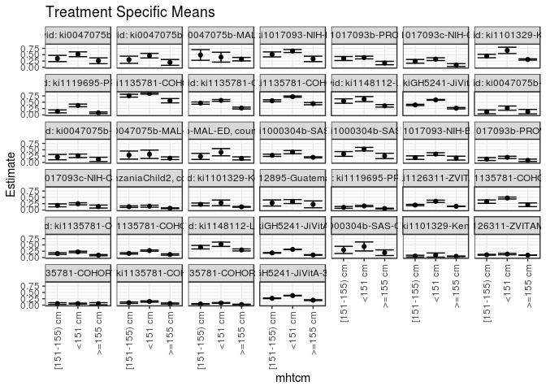

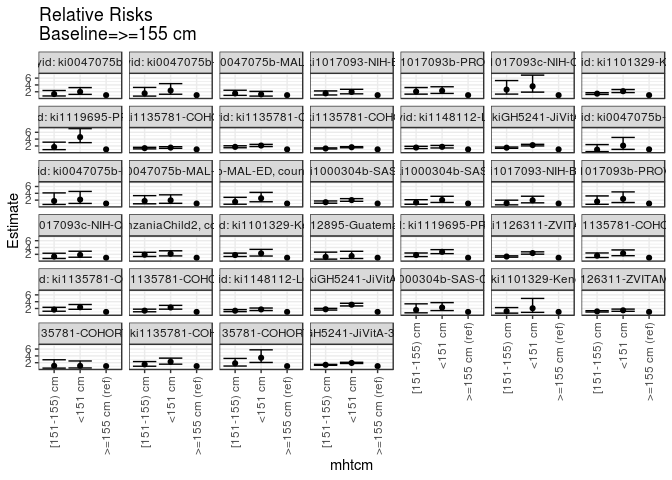

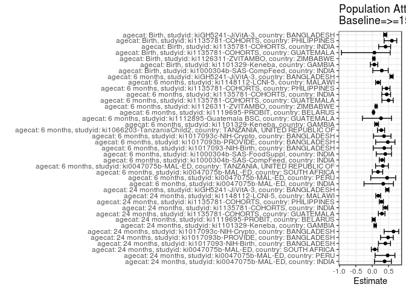

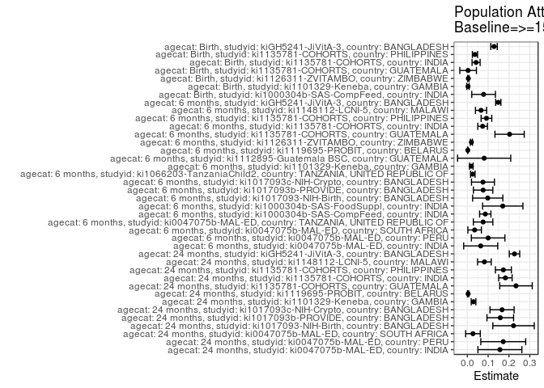

## Results Table

### Parameter: TSM

| agecat | studyid | country | intervention_level | baseline_level | estimate | ci_lower | ci_upper |
| --- | --- | --- | --- | --- | --- | --- | --- |
| Birth | ki1000304b-SAS-CompFeed | INDIA | >=155 cm | NA | 0.1911981 | 0.0794579 | 0.3029383 |
| Birth | ki1000304b-SAS-CompFeed | INDIA | <151 cm | NA | 0.4380976 | 0.2604791 | 0.6157161 |
| Birth | ki1000304b-SAS-CompFeed | INDIA | [151-155) cm | NA | 0.3019921 | 0.1607768 | 0.4432074 |
| Birth | ki1101329-Keneba | GAMBIA | >=155 cm | NA | 0.0472175 | 0.0351420 | 0.0592931 |
| Birth | ki1101329-Keneba | GAMBIA | <151 cm | NA | 0.0980392 | 0.0163981 | 0.1796803 |
| Birth | ki1101329-Keneba | GAMBIA | [151-155) cm | NA | 0.0572917 | 0.0244077 | 0.0901756 |
| Birth | ki1126311-ZVITAMBO | ZIMBABWE | >=155 cm | NA | 0.0943349 | 0.0878053 | 0.1008646 |
| Birth | ki1126311-ZVITAMBO | ZIMBABWE | <151 cm | NA | 0.1388306 | 0.1101340 | 0.1675272 |
| Birth | ki1126311-ZVITAMBO | ZIMBABWE | [151-155) cm | NA | 0.1092578 | 0.0929482 | 0.1255675 |
| Birth | ki1135781-COHORTS | GUATEMALA | >=155 cm | NA | 0.0545455 | 0.0120825 | 0.0970084 |
| Birth | ki1135781-COHORTS | GUATEMALA | <151 cm | NA | 0.0587156 | 0.0389666 | 0.0784646 |
| Birth | ki1135781-COHORTS | GUATEMALA | [151-155) cm | NA | 0.0594595 | 0.0253621 | 0.0935568 |
| Birth | ki1135781-COHORTS | INDIA | >=155 cm | NA | 0.0617231 | 0.0410517 | 0.0823944 |
| Birth | ki1135781-COHORTS | INDIA | <151 cm | NA | 0.1413535 | 0.1167111 | 0.1659959 |
| Birth | ki1135781-COHORTS | INDIA | [151-155) cm | NA | 0.0931476 | 0.0669362 | 0.1193590 |
| Birth | ki1135781-COHORTS | PHILIPPINES | >=155 cm | NA | 0.0246096 | 0.0126625 | 0.0365567 |
| Birth | ki1135781-COHORTS | PHILIPPINES | <151 cm | NA | 0.0850350 | 0.0710936 | 0.0989764 |
| Birth | ki1135781-COHORTS | PHILIPPINES | [151-155) cm | NA | 0.0450341 | 0.0310545 | 0.0590137 |
| Birth | kiGH5241-JiVitA-3 | BANGLADESH | >=155 cm | NA | 0.1948554 | 0.1784352 | 0.2112757 |
| Birth | kiGH5241-JiVitA-3 | BANGLADESH | <151 cm | NA | 0.3772100 | 0.3672678 | 0.3871522 |
| Birth | kiGH5241-JiVitA-3 | BANGLADESH | [151-155) cm | NA | 0.2689499 | 0.2551351 | 0.2827647 |
| 6 months | ki0047075b-MAL-ED | INDIA | >=155 cm | NA | 0.1272727 | 0.0390055 | 0.2155400 |
| 6 months | ki0047075b-MAL-ED | INDIA | <151 cm | NA | 0.2678571 | 0.1856680 | 0.3500463 |
| 6 months | ki0047075b-MAL-ED | INDIA | [151-155) cm | NA | 0.1176471 | 0.0409054 | 0.1943887 |
| 6 months | ki0047075b-MAL-ED | PERU | >=155 cm | NA | 0.1206897 | 0.0366973 | 0.2046821 |
| 6 months | ki0047075b-MAL-ED | PERU | <151 cm | NA | 0.2611465 | 0.1923099 | 0.3299831 |
| 6 months | ki0047075b-MAL-ED | PERU | [151-155) cm | NA | 0.2105263 | 0.1044954 | 0.3165572 |
| 6 months | ki0047075b-MAL-ED | SOUTH AFRICA | >=155 cm | NA | 0.1657754 | 0.1123679 | 0.2191830 |
| 6 months | ki0047075b-MAL-ED | SOUTH AFRICA | <151 cm | NA | 0.3225806 | 0.1576927 | 0.4874686 |
| 6 months | ki0047075b-MAL-ED | SOUTH AFRICA | [151-155) cm | NA | 0.2903226 | 0.1302150 | 0.4504302 |

[output cut: 87 more lines]

### Parameter: E(Y)

| agecat | studyid | country | intervention_level | baseline_level | estimate | ci_lower | ci_upper |
| --- | --- | --- | --- | --- | --- | --- | --- |
| Birth | ki1000304b-SAS-CompFeed | INDIA | NA | NA | 0.2692308 | 0.1695525 | 0.3689090 |
| Birth | ki1101329-Keneba | GAMBIA | NA | NA | 0.0503849 | 0.0390398 | 0.0617300 |
| Birth | ki1126311-ZVITAMBO | ZIMBABWE | NA | NA | 0.0991000 | 0.0931434 | 0.1050567 |
| Birth | ki1135781-COHORTS | GUATEMALA | NA | NA | 0.0583333 | 0.0424744 | 0.0741923 |
| Birth | ki1135781-COHORTS | INDIA | NA | NA | 0.1037204 | 0.0895283 | 0.1179125 |
| Birth | ki1135781-COHORTS | PHILIPPINES | NA | NA | 0.0613115 | 0.0527962 | 0.0698268 |
| Birth | kiGH5241-JiVitA-3 | BANGLADESH | NA | NA | 0.3230958 | 0.3154261 | 0.3307655 |
| 6 months | ki0047075b-MAL-ED | INDIA | NA | NA | 0.1914894 | 0.1410749 | 0.2419038 |
| 6 months | ki0047075b-MAL-ED | PERU | NA | NA | 0.2205882 | 0.1712211 | 0.2699554 |
| 6 months | ki0047075b-MAL-ED | SOUTH AFRICA | NA | NA | 0.2008032 | 0.1509453 | 0.2506612 |
| 6 months | ki0047075b-MAL-ED | TANZANIA, UNITED REPUBLIC OF | NA | NA | 0.2348178 | 0.1818480 | 0.2877876 |
| 6 months | ki1000304b-SAS-CompFeed | INDIA | NA | NA | 0.2882736 | 0.2624662 | 0.3140810 |
| 6 months | ki1000304b-SAS-FoodSuppl | INDIA | NA | NA | 0.4274406 | 0.3775694 | 0.4773119 |
| 6 months | ki1017093-NIH-Birth | BANGLADESH | NA | NA | 0.2681564 | 0.2306532 | 0.3056597 |
| 6 months | ki1017093b-PROVIDE | BANGLADESH | NA | NA | 0.1597938 | 0.1299995 | 0.1895881 |
| 6 months | ki1017093c-NIH-Crypto | BANGLADESH | NA | NA | 0.2097902 | 0.1799252 | 0.2396552 |
| 6 months | ki1066203-TanzaniaChild2 | TANZANIA, UNITED REPUBLIC OF | NA | NA | 0.0951904 | 0.0823123 | 0.1080685 |
| 6 months | ki1101329-Keneba | GAMBIA | NA | NA | 0.1427810 | 0.1269499 | 0.1586122 |
| 6 months | ki1112895-Guatemala BSC | GUATEMALA | NA | NA | 0.3030303 | 0.2436375 | 0.3624232 |
| 6 months | ki1119695-PROBIT | BELARUS | NA | NA | 0.0598481 | 0.0470397 | 0.0726565 |
| 6 months | ki1126311-ZVITAMBO | ZIMBABWE | NA | NA | 0.1655908 | 0.1569598 | 0.1742218 |
| 6 months | ki1135781-COHORTS | GUATEMALA | NA | NA | 0.4093319 | 0.3779317 | 0.4407321 |
| 6 months | ki1135781-COHORTS | INDIA | NA | NA | 0.1665750 | 0.1494477 | 0.1837024 |
| 6 months | ki1135781-COHORTS | PHILIPPINES | NA | NA | 0.2112260 | 0.1958496 | 0.2266024 |
| 6 months | ki1148112-LCNI-5 | MALAWI | NA | NA | 0.3672249 | 0.3345288 | 0.3999210 |
| 6 months | kiGH5241-JiVitA-3 | BANGLADESH | NA | NA | 0.2515363 | 0.2434210 | 0.2596516 |
| 24 months | ki0047075b-MAL-ED | INDIA | NA | NA | 0.4159292 | 0.3515272 | 0.4803312 |
| 24 months | ki0047075b-MAL-ED | PERU | NA | NA | 0.3681592 | 0.3013164 | 0.4350020 |
| 24 months | ki0047075b-MAL-ED | SOUTH AFRICA | NA | NA | 0.3504274 | 0.2891665 | 0.4116882 |
| 24 months | ki1017093-NIH-Birth | BANGLADESH | NA | NA | 0.5547786 | 0.5076945 | 0.6018626 |
| 24 months | ki1017093b-PROVIDE | BANGLADESH | NA | NA | 0.3281250 | 0.2897474 | 0.3665026 |
| 24 months | ki1017093c-NIH-Crypto | BANGLADESH | NA | NA | 0.2568093 | 0.2190047 | 0.2946140 |
| 24 months | ki1101329-Keneba | GAMBIA | NA | NA | 0.3395755 | 0.3163785 | 0.3627726 |
| 24 months | ki1119695-PROBIT | BELARUS | NA | NA | 0.0853933 | 0.0554084 | 0.1153781 |
| 24 months | ki1135781-COHORTS | GUATEMALA | NA | NA | 0.7933801 | 0.7682355 | 0.8185248 |
| 24 months | ki1135781-COHORTS | INDIA | NA | NA | 0.4524464 | 0.4295668 | 0.4753260 |
| 24 months | ki1135781-COHORTS | PHILIPPINES | NA | NA | 0.6167689 | 0.5974942 | 0.6360437 |
| 24 months | ki1148112-LCNI-5 | MALAWI | NA | NA | 0.4402080 | 0.3996684 | 0.4807475 |
| 24 months | kiGH5241-JiVitA-3 | BANGLADESH | NA | NA | 0.4911036 | 0.4779420 | 0.5042652 |

### Parameter: RR

| agecat | studyid | country | intervention_level | baseline_level | estimate | ci_lower | ci_upper |
| --- | --- | --- | --- | --- | --- | --- | --- |
| Birth | ki1000304b-SAS-CompFeed | INDIA | >=155 cm | >=155 cm | 1.0000000 | 1.0000000 | 1.000000 |
| Birth | ki1000304b-SAS-CompFeed | INDIA | <151 cm | >=155 cm | 2.2913283 | 1.4056682 | 3.735010 |
| Birth | ki1000304b-SAS-CompFeed | INDIA | [151-155) cm | >=155 cm | 1.5794722 | 0.7402214 | 3.370252 |
| Birth | ki1101329-Keneba | GAMBIA | >=155 cm | >=155 cm | 1.0000000 | 1.0000000 | 1.000000 |
| Birth | ki1101329-Keneba | GAMBIA | <151 cm | >=155 cm | 2.0763305 | 0.8689039 | 4.961594 |
| Birth | ki1101329-Keneba | GAMBIA | [151-155) cm | >=155 cm | 1.2133556 | 0.6472765 | 2.274502 |
| Birth | ki1126311-ZVITAMBO | ZIMBABWE | >=155 cm | >=155 cm | 1.0000000 | 1.0000000 | 1.000000 |
| Birth | ki1126311-ZVITAMBO | ZIMBABWE | <151 cm | >=155 cm | 1.4716775 | 1.1834193 | 1.830150 |
| Birth | ki1126311-ZVITAMBO | ZIMBABWE | [151-155) cm | >=155 cm | 1.1581907 | 0.9824727 | 1.365336 |
| Birth | ki1135781-COHORTS | GUATEMALA | >=155 cm | >=155 cm | 1.0000000 | 1.0000000 | 1.000000 |
| Birth | ki1135781-COHORTS | GUATEMALA | <151 cm | >=155 cm | 1.0764526 | 0.4609940 | 2.513591 |
| Birth | ki1135781-COHORTS | GUATEMALA | [151-155) cm | >=155 cm | 1.0900901 | 0.4145183 | 2.866692 |
| Birth | ki1135781-COHORTS | INDIA | >=155 cm | >=155 cm | 1.0000000 | 1.0000000 | 1.000000 |
| Birth | ki1135781-COHORTS | INDIA | <151 cm | >=155 cm | 2.2901245 | 1.5696980 | 3.341197 |
| Birth | ki1135781-COHORTS | INDIA | [151-155) cm | >=155 cm | 1.5091212 | 0.9747871 | 2.336353 |
| Birth | ki1135781-COHORTS | PHILIPPINES | >=155 cm | >=155 cm | 1.0000000 | 1.0000000 | 1.000000 |
| Birth | ki1135781-COHORTS | PHILIPPINES | <151 cm | >=155 cm | 3.4553558 | 2.0702454 | 5.767183 |
| Birth | ki1135781-COHORTS | PHILIPPINES | [151-155) cm | >=155 cm | 1.8299399 | 1.0282850 | 3.256568 |
| Birth | kiGH5241-JiVitA-3 | BANGLADESH | >=155 cm | >=155 cm | 1.0000000 | 1.0000000 | 1.000000 |
| Birth | kiGH5241-JiVitA-3 | BANGLADESH | <151 cm | >=155 cm | 1.9358455 | 1.7727495 | 2.113947 |
| Birth | kiGH5241-JiVitA-3 | BANGLADESH | [151-155) cm | >=155 cm | 1.3802534 | 1.2523430 | 1.521228 |
| 6 months | ki0047075b-MAL-ED | INDIA | >=155 cm | >=155 cm | 1.0000000 | 1.0000000 | 1.000000 |
| 6 months | ki0047075b-MAL-ED | INDIA | <151 cm | >=155 cm | 2.1045918 | 0.9858478 | 4.492891 |
| 6 months | ki0047075b-MAL-ED | INDIA | [151-155) cm | >=155 cm | 0.9243697 | 0.3567439 | 2.395162 |
| 6 months | ki0047075b-MAL-ED | PERU | >=155 cm | >=155 cm | 1.0000000 | 1.0000000 | 1.000000 |
| 6 months | ki0047075b-MAL-ED | PERU | <151 cm | >=155 cm | 2.1637853 | 1.0280615 | 4.554170 |
| 6 months | ki0047075b-MAL-ED | PERU | [151-155) cm | >=155 cm | 1.7443609 | 0.7388397 | 4.118343 |
| 6 months | ki0047075b-MAL-ED | SOUTH AFRICA | >=155 cm | >=155 cm | 1.0000000 | 1.0000000 | 1.000000 |
| 6 months | ki0047075b-MAL-ED | SOUTH AFRICA | <151 cm | >=155 cm | 1.9458897 | 1.0634406 | 3.560600 |
| 6 months | ki0047075b-MAL-ED | SOUTH AFRICA | [151-155) cm | >=155 cm | 1.7513007 | 0.9246585 | 3.316959 |

[output cut: 87 more lines]

### Parameter: PAR

| agecat | studyid | country | intervention_level | baseline_level | estimate | ci_lower | ci_upper |
| --- | --- | --- | --- | --- | --- | --- | --- |
| Birth | ki1000304b-SAS-CompFeed | INDIA | >=155 cm | NA | 0.0780327 | 0.0212258 | 0.1348396 |
| Birth | ki1101329-Keneba | GAMBIA | >=155 cm | NA | 0.0031673 | -0.0025322 | 0.0088669 |
| Birth | ki1126311-ZVITAMBO | ZIMBABWE | >=155 cm | NA | 0.0047651 | 0.0015763 | 0.0079539 |
| Birth | ki1135781-COHORTS | GUATEMALA | >=155 cm | NA | 0.0037879 | -0.0359911 | 0.0435668 |
| Birth | ki1135781-COHORTS | INDIA | >=155 cm | NA | 0.0419973 | 0.0226414 | 0.0613533 |
| Birth | ki1135781-COHORTS | PHILIPPINES | >=155 cm | NA | 0.0367019 | 0.0242621 | 0.0491416 |
| Birth | kiGH5241-JiVitA-3 | BANGLADESH | >=155 cm | NA | 0.1282404 | 0.1126715 | 0.1438093 |
| 6 months | ki0047075b-MAL-ED | INDIA | >=155 cm | NA | 0.0642166 | -0.0175503 | 0.1459836 |
| 6 months | ki0047075b-MAL-ED | PERU | >=155 cm | NA | 0.0998986 | 0.0193802 | 0.1804169 |
| 6 months | ki0047075b-MAL-ED | SOUTH AFRICA | >=155 cm | NA | 0.0350278 | 0.0025639 | 0.0674917 |
| 6 months | ki0047075b-MAL-ED | TANZANIA, UNITED REPUBLIC OF | >=155 cm | NA | 0.0757867 | 0.0290142 | 0.1225592 |
| 6 months | ki1000304b-SAS-CompFeed | INDIA | >=155 cm | NA | 0.0861244 | 0.0589634 | 0.1132854 |
| 6 months | ki1000304b-SAS-FoodSuppl | INDIA | >=155 cm | NA | 0.1700454 | 0.0731421 | 0.2669487 |
| 6 months | ki1017093-NIH-Birth | BANGLADESH | >=155 cm | NA | 0.0980604 | 0.0254958 | 0.1706250 |
| 6 months | ki1017093b-PROVIDE | BANGLADESH | >=155 cm | NA | 0.0758049 | 0.0292075 | 0.1224024 |
| 6 months | ki1017093c-NIH-Crypto | BANGLADESH | >=155 cm | NA | 0.0750546 | 0.0199634 | 0.1301459 |
| 6 months | ki1066203-TanzaniaChild2 | TANZANIA, UNITED REPUBLIC OF | >=155 cm | NA | 0.0262709 | 0.0154500 | 0.0370918 |
| 6 months | ki1101329-Keneba | GAMBIA | >=155 cm | NA | 0.0190980 | 0.0105916 | 0.0276044 |
| 6 months | ki1112895-Guatemala BSC | GUATEMALA | >=155 cm | NA | 0.0808081 | -0.0467748 | 0.2083909 |
| 6 months | ki1119695-PROBIT | BELARUS | >=155 cm | NA | 0.0022486 | 0.0012147 | 0.0032825 |
| 6 months | ki1126311-ZVITAMBO | ZIMBABWE | >=155 cm | NA | 0.0195001 | 0.0145527 | 0.0244475 |
| 6 months | ki1135781-COHORTS | GUATEMALA | >=155 cm | NA | 0.2029972 | 0.1326746 | 0.2733198 |
| 6 months | ki1135781-COHORTS | INDIA | >=155 cm | NA | 0.0733976 | 0.0502456 | 0.0965496 |
| 6 months | ki1135781-COHORTS | PHILIPPINES | >=155 cm | NA | 0.0918249 | 0.0662265 | 0.1174233 |
| 6 months | ki1148112-LCNI-5 | MALAWI | >=155 cm | NA | 0.0657819 | 0.0390394 | 0.0925244 |
| 6 months | kiGH5241-JiVitA-3 | BANGLADESH | >=155 cm | NA | 0.1486207 | 0.1359769 | 0.1612644 |
| 24 months | ki0047075b-MAL-ED | INDIA | >=155 cm | NA | 0.1564529 | 0.0509335 | 0.2619724 |
| 24 months | ki0047075b-MAL-ED | PERU | >=155 cm | NA | 0.1725070 | 0.0646625 | 0.2803516 |
| 24 months | ki0047075b-MAL-ED | SOUTH AFRICA | >=155 cm | NA | 0.0270413 | -0.0081025 | 0.0621851 |
| 24 months | ki1017093-NIH-Birth | BANGLADESH | >=155 cm | NA | 0.2219632 | 0.1224731 | 0.3214534 |
| 24 months | ki1017093b-PROVIDE | BANGLADESH | >=155 cm | NA | 0.1582365 | 0.0942503 | 0.2222226 |
| 24 months | ki1017093c-NIH-Crypto | BANGLADESH | >=155 cm | NA | 0.1668093 | 0.1088878 | 0.2247309 |
| 24 months | ki1101329-Keneba | GAMBIA | >=155 cm | NA | 0.0297920 | 0.0185553 | 0.0410286 |
| 24 months | ki1119695-PROBIT | BELARUS | >=155 cm | NA | 0.0037577 | 0.0004712 | 0.0070442 |
| 24 months | ki1135781-COHORTS | GUATEMALA | >=155 cm | NA | 0.2337563 | 0.1557500 | 0.3117626 |
| 24 months | ki1135781-COHORTS | INDIA | >=155 cm | NA | 0.1828707 | 0.1505639 | 0.2151775 |
| 24 months | ki1135781-COHORTS | PHILIPPINES | >=155 cm | NA | 0.1730749 | 0.1347047 | 0.2114450 |
| 24 months | ki1148112-LCNI-5 | MALAWI | >=155 cm | NA | 0.0819712 | 0.0491752 | 0.1147673 |
| 24 months | kiGH5241-JiVitA-3 | BANGLADESH | >=155 cm | NA | 0.2264724 | 0.2013906 | 0.2515542 |

### Parameter: PAF

| agecat | studyid | country | intervention_level | baseline_level | estimate | ci_lower | ci_upper |
| --- | --- | --- | --- | --- | --- | --- | --- |
| Birth | ki1000304b-SAS-CompFeed | INDIA | >=155 cm | NA | 0.2898356 | 0.0169378 | 0.4869771 |
| Birth | ki1101329-Keneba | GAMBIA | >=155 cm | NA | 0.0628630 | -0.0564656 | 0.1687134 |
| Birth | ki1126311-ZVITAMBO | ZIMBABWE | >=155 cm | NA | 0.0480838 | 0.0154591 | 0.0796274 |
| Birth | ki1135781-COHORTS | GUATEMALA | >=155 cm | NA | 0.0649351 | -0.9385216 | 0.5489623 |
| Birth | ki1135781-COHORTS | INDIA | >=155 cm | NA | 0.4049092 | 0.1951119 | 0.5600220 |
| Birth | ki1135781-COHORTS | PHILIPPINES | >=155 cm | NA | 0.5986133 | 0.3619177 | 0.7475071 |
| Birth | kiGH5241-JiVitA-3 | BANGLADESH | >=155 cm | NA | 0.3969113 | 0.3471007 | 0.4429218 |
| 6 months | ki0047075b-MAL-ED | INDIA | >=155 cm | NA | 0.3353535 | -0.2516652 | 0.6470662 |
| 6 months | ki0047075b-MAL-ED | PERU | >=155 cm | NA | 0.4528736 | -0.0471592 | 0.7141339 |
| 6 months | ki0047075b-MAL-ED | SOUTH AFRICA | >=155 cm | NA | 0.1744385 | 0.0000171 | 0.3184365 |
| 6 months | ki0047075b-MAL-ED | TANZANIA, UNITED REPUBLIC OF | >=155 cm | NA | 0.3227468 | 0.1005116 | 0.4900747 |
| 6 months | ki1000304b-SAS-CompFeed | INDIA | >=155 cm | NA | 0.2987592 | 0.2154938 | 0.3731870 |
| 6 months | ki1000304b-SAS-FoodSuppl | INDIA | >=155 cm | NA | 0.3978223 | 0.1217824 | 0.5870979 |
| 6 months | ki1017093-NIH-Birth | BANGLADESH | >=155 cm | NA | 0.3656835 | 0.0320003 | 0.5843414 |
| 6 months | ki1017093b-PROVIDE | BANGLADESH | >=155 cm | NA | 0.4743923 | 0.1036538 | 0.6917893 |
| 6 months | ki1017093c-NIH-Crypto | BANGLADESH | >=155 cm | NA | 0.3577605 | 0.0381242 | 0.5711800 |
| 6 months | ki1066203-TanzaniaChild2 | TANZANIA, UNITED REPUBLIC OF | >=155 cm | NA | 0.2759827 | 0.1590336 | 0.3766683 |
| 6 months | ki1101329-Keneba | GAMBIA | >=155 cm | NA | 0.1337573 | 0.0735707 | 0.1900339 |
| 6 months | ki1112895-Guatemala BSC | GUATEMALA | >=155 cm | NA | 0.2666667 | -0.2999982 | 0.5863242 |
| 6 months | ki1119695-PROBIT | BELARUS | >=155 cm | NA | 0.0375721 | 0.0223058 | 0.0526000 |
| 6 months | ki1126311-ZVITAMBO | ZIMBABWE | >=155 cm | NA | 0.1177609 | 0.0877968 | 0.1467407 |
| 6 months | ki1135781-COHORTS | GUATEMALA | >=155 cm | NA | 0.4959232 | 0.2931776 | 0.6405130 |
| 6 months | ki1135781-COHORTS | INDIA | >=155 cm | NA | 0.4406278 | 0.2904337 | 0.5590302 |
| 6 months | ki1135781-COHORTS | PHILIPPINES | >=155 cm | NA | 0.4347234 | 0.3031753 | 0.5414376 |
| 6 months | ki1148112-LCNI-5 | MALAWI | >=155 cm | NA | 0.1791325 | 0.1031268 | 0.2486971 |
| 6 months | kiGH5241-JiVitA-3 | BANGLADESH | >=155 cm | NA | 0.5908518 | 0.5401039 | 0.6359998 |
| 24 months | ki0047075b-MAL-ED | INDIA | >=155 cm | NA | 0.3761528 | 0.0668043 | 0.5829543 |
| 24 months | ki0047075b-MAL-ED | PERU | >=155 cm | NA | 0.4685664 | 0.0859712 | 0.6910145 |
| 24 months | ki0047075b-MAL-ED | SOUTH AFRICA | >=155 cm | NA | 0.0771666 | -0.0287878 | 0.1722088 |
| 24 months | ki1017093-NIH-Birth | BANGLADESH | >=155 cm | NA | 0.4000934 | 0.1889136 | 0.5562890 |
| 24 months | ki1017093b-PROVIDE | BANGLADESH | >=155 cm | NA | 0.4822444 | 0.2522313 | 0.6415057 |
| 24 months | ki1017093c-NIH-Crypto | BANGLADESH | >=155 cm | NA | 0.6495454 | 0.3626160 | 0.8073086 |
| 24 months | ki1101329-Keneba | GAMBIA | >=155 cm | NA | 0.0877330 | 0.0540700 | 0.1201980 |
| 24 months | ki1119695-PROBIT | BELARUS | >=155 cm | NA | 0.0440049 | -0.0037695 | 0.0895054 |
| 24 months | ki1135781-COHORTS | GUATEMALA | >=155 cm | NA | 0.2946334 | 0.1869356 | 0.3880657 |
| 24 months | ki1135781-COHORTS | INDIA | >=155 cm | NA | 0.4041820 | 0.3285203 | 0.4713183 |
| 24 months | ki1135781-COHORTS | PHILIPPINES | >=155 cm | NA | 0.2806154 | 0.2147405 | 0.3409641 |
| 24 months | ki1148112-LCNI-5 | MALAWI | >=155 cm | NA | 0.1862102 | 0.1075918 | 0.2579026 |
| 24 months | kiGH5241-JiVitA-3 | BANGLADESH | >=155 cm | NA | 0.4611500 | 0.4066466 | 0.5106469 |